# HT3

```
##
##  Lilliefors (Kolmogorov-Smirnov) normality test
##
## data:  datos$OpenPorchSF
## D = 0.24064, p-value < 2.2e-16
```

###X3SsnPorch

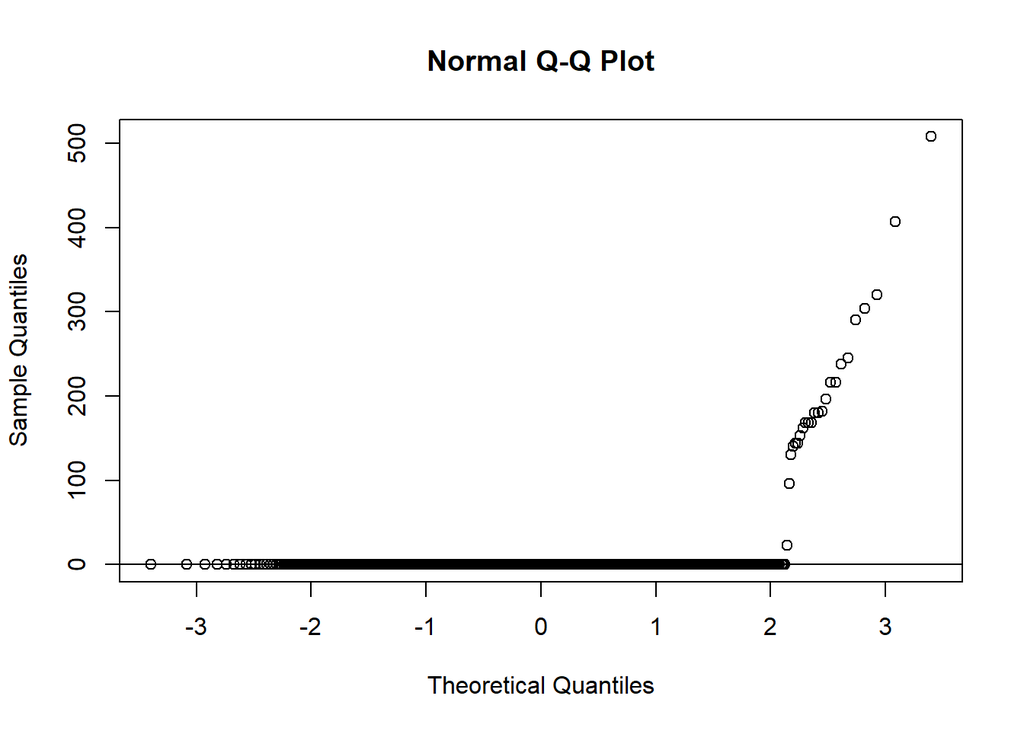

```
##
##  Lilliefors (Kolmogorov-Smirnov) normality test
##
## data:  datos$X3SsnPorch
## D = 0.52985, p-value < 2.2e-16
```

[figure not shown]

[output not shown]

###ScreenPorch

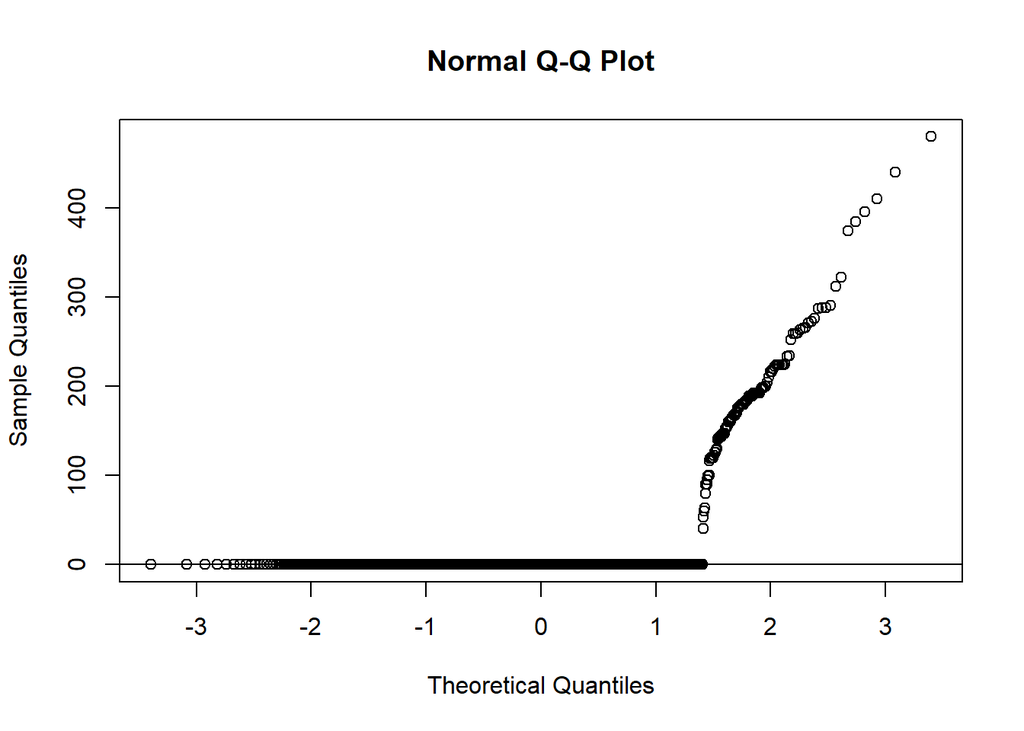

```
##
##  Lilliefors (Kolmogorov-Smirnov) normality test
##
## data:  datos$ScreenPorch
## D = 0.52701, p-value < 2.2e-16
```

###PoolArea

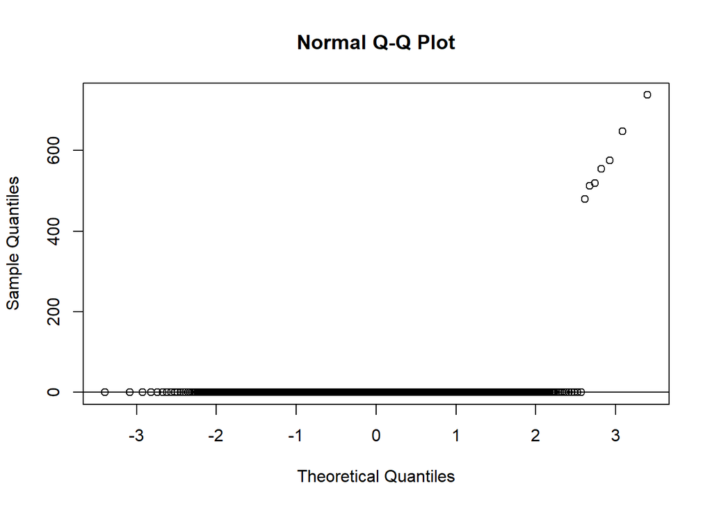

```
##
##  Lilliefors (Kolmogorov-Smirnov) normality test
##
## data:  datos$PoolArea
## D = 0.52258, p-value < 2.2e-16
```

###MiscVal

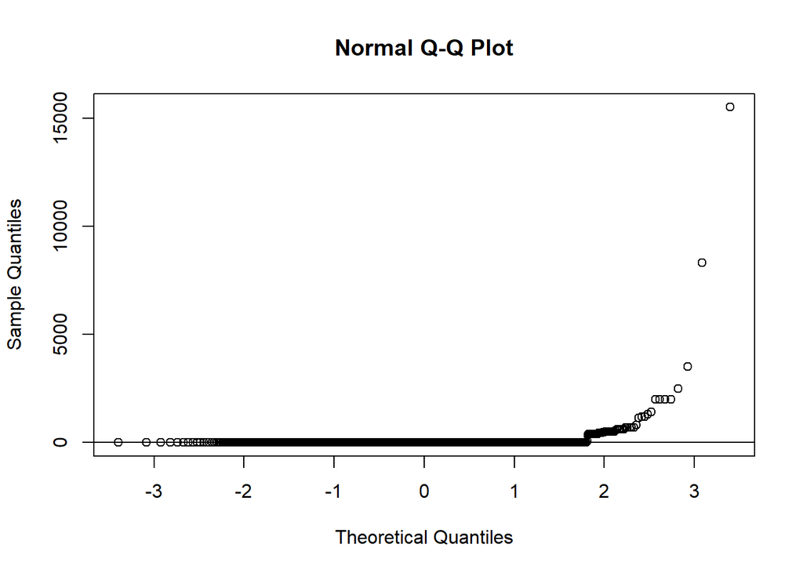

```
##
##  Lilliefors (Kolmogorov-Smirnov) normality test
##
## data:  datos$MiscVal
## D = 0.49931, p-value < 2.2e-16
```

###MoSold

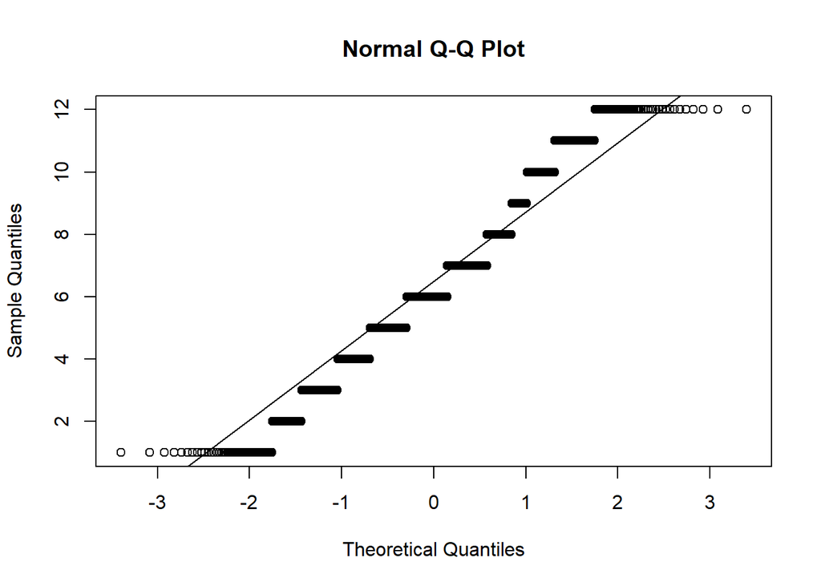

```
##
##  Lilliefors (Kolmogorov-Smirnov) normality test
##
## data:  datos$MoSold
## D = 0.11879, p-value < 2.2e-16
```

###YrSold

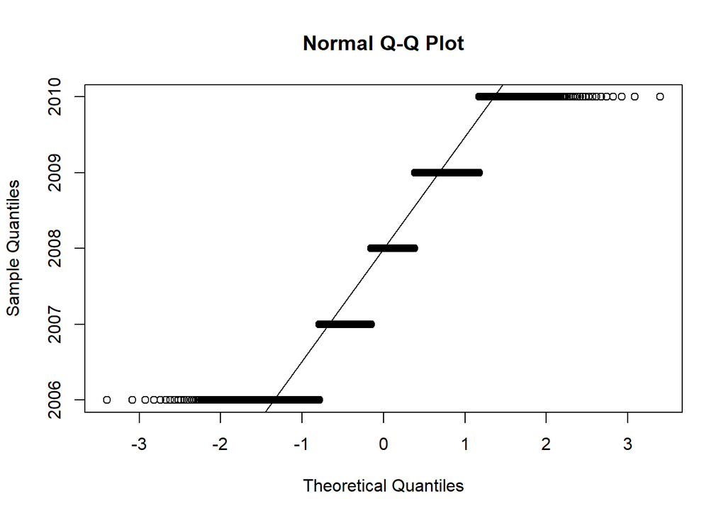

```
##
##  Lilliefors (Kolmogorov-Smirnov) normality test
##
## data:  datos$YrSold
## D = 0.17088, p-value < 2.2e-16
```

###SalePrice

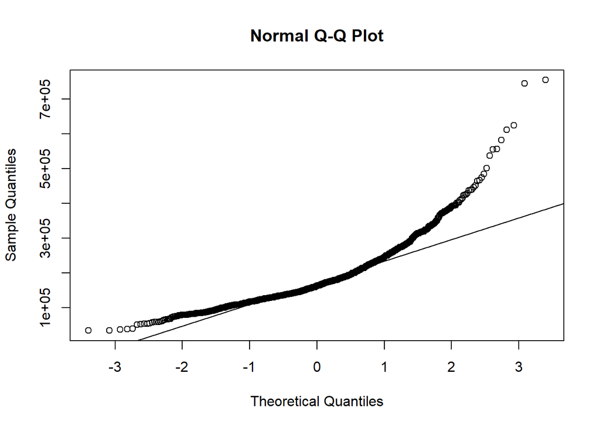

```
##
##  Lilliefors (Kolmogorov-Smirnov) normality test
##
## data:  datos$SalePrice
## D = 0.12369, p-value < 2.2e-16
```

Se puede confirmar observando las pruebas de normalidad y las gráficas que las variables no respetan una distribución normal

Se escalan las variables y se saca la matriz de correlaciones para observar a que variables es más sensible el precio de venta.

```
##                          Id   MSSubClass LotFrontage      LotArea OverallQual
## Id             1.0000000000  0.011156478          NA -0.033225519 -0.02836475
## MSSubClass     0.0111564782  1.000000000          NA -0.139781082  0.03262771
## LotFrontage              NA           NA           1           NA          NA
## LotArea       -0.0332255186 -0.139781082          NA  1.000000000  0.10580574
## OverallQual   -0.0283647539  0.032627708          NA  0.105805742  1.00000000
## OverallCond    0.0126089248 -0.059315817          NA -0.005636270 -0.09193234
## YearBuilt     -0.0127127154  0.027850137          NA  0.014227652  0.57232277
## YearRemodAdd  -0.0219976419  0.040581045          NA  0.013788427  0.55068392
## MasVnrArea               NA           NA          NA           NA          NA
## BsmtFinSF1    -0.0050240490 -0.069835749          NA  0.214103131  0.23966597
## BsmtFinSF2    -0.0059676720 -0.065648579          NA  0.111169745 -0.05911869
## BsmtUnfSF     -0.0079397034 -0.140759481          NA -0.002618360  0.30815893
## TotalBsmtSF   -0.0154145661 -0.238518409          NA  0.260833135  0.53780850
## X1stFlrSF      0.0104960410 -0.251758352          NA  0.299474579  0.47622383
## X2ndFlrSF      0.0055898489  0.307885721          NA  0.050985948  0.29549288
## LowQualFinSF  -0.0442299581  0.046473756          NA  0.004778970 -0.03042928
## GrLivArea      0.0082727577  0.074853180          NA  0.263116167  0.59300743
## BsmtFullBath   0.0022885556  0.003491026          NA  0.158154531  0.11109779
## BsmtHalfBath  -0.0201547452 -0.002332535          NA  0.048045571 -0.04015016
## FullBath       0.0055874529  0.131608222          NA  0.126030627  0.55059971
## HalfBath       0.0067838113  0.177354389          NA  0.014259469  0.27345810
## BedroomAbvGr   0.0377185542 -0.023438028          NA  0.119689908  0.10167636
## KitchenAbvGr   0.0029512364  0.281721040          NA -0.017783871 -0.18388223
## TotRmsAbvGrd   0.0272387244  0.040380065          NA  0.190014778  0.42745234
## Fireplaces    -0.0197716324 -0.045569340          NA  0.271364010  0.39676504
## GarageYrBlt              NA           NA          NA           NA          NA
## GarageCars     0.0165696771 -0.040109793          NA  0.154870740  0.60067072
## GarageArea     0.0176337785 -0.098671543          NA  0.180402755  0.56202176
## WoodDeckSF    -0.0296431972 -0.012579358          NA  0.171697687  0.23892339
## OpenPorchSF   -0.0004769113 -0.006100121          NA  0.084773809  0.30881882
## EnclosedPorch  0.0028892179 -0.012036622          NA -0.018339734 -0.11393686
## X3SsnPorch    -0.0466347889 -0.043824549          NA  0.020422830  0.03037057
## ScreenPorch    0.0013302086 -0.026030177          NA  0.043160378  0.06488636
## PoolArea       0.0570439048  0.008282708          NA  0.077672392  0.06516584
## MiscVal       -0.0062424048 -0.007683291          NA  0.038067692 -0.03140621
## MoSold         0.0211721766 -0.013584643          NA  0.001204988  0.07081517
## YrSold         0.0007117940 -0.021407038          NA -0.014261407 -0.02734671
## SalePrice     -0.0219167194 -0.084284135          NA  0.263843354  0.79098160
##                OverallCond    YearBuilt YearRemodAdd MasVnrArea   BsmtFinSF1
```

[output cut: 257 more lines]

```
## TotRmsAbvGrd   0.083757350  0.0247628842  0.036907077 -0.034516354  0.53372316
## Fireplaces     0.095073522  0.0014086054  0.046357102 -0.024095565  0.46692884
## GarageYrBlt             NA            NA           NA           NA          NA
## GarageCars     0.020933531 -0.0430801281  0.040521730 -0.039116904  0.64040920
## GarageArea     0.061047272 -0.0273999144  0.027973800 -0.027377940  0.62343144
## WoodDeckSF     0.073378207 -0.0095512282  0.021011044  0.022270451  0.32441344
## OpenPorchSF    0.060762111 -0.0185837390  0.071254885 -0.057619360  0.31585623
## EnclosedPorch  0.054202562  0.0183606001 -0.028887266 -0.009915937 -0.12857796
## X3SsnPorch    -0.007991549  0.0003539653  0.029473795  0.018644925  0.04458367
## ScreenPorch    0.051307395  0.0319457608  0.023216992  0.010694106  0.11144657
## PoolArea       1.000000000  0.0296686509 -0.033736640 -0.059688932  0.09240355
## MiscVal        0.029668651  1.0000000000 -0.006494550  0.004906262 -0.02118958
## MoSold        -0.033736640 -0.0064945502  1.000000000 -0.145721413  0.04643225
## YrSold        -0.059688932  0.0049062625 -0.145721413  1.000000000 -0.02892259
## SalePrice      0.092403549 -0.0211895796  0.046432245 -0.028922585  1.00000000
```

Observando las correlaciones se puede notar que las variables OverallQual y GrLivArea son las que tienen una correlación en valor absoluto mayor a 0.7, por lo tanto, deben ser las que se tomaran en cuenta en el modelo.

##Pregunta 4. Particion de los datos en dos conjuntos

Como los datos están balanceados se hizo una partición aleatoria utilizando el 70% de los datos para entrenamiento y el 30% de los datos para prueba.

```r
porcentaje<-0.7
set.seed(123)
corte <- sample(nrow(datosc),nrow(datosc)*porcentaje)
training<-datos[corte,]
test<-datos[-corte,]
```

[output not shown]

[output cut: 76 more lines]

###Conjunto de Prueba (cantidad de muestras: 439):

```r
head(test)
```

```
##    Id MSSubClass MSZoning LotFrontage LotArea Street Alley LotShape LandContour
## 1   1         60       RL          65    8450   Pave  <NA>      Reg         Lvl
## 3   3         60       RL          68   11250   Pave  <NA>      IR1         Lvl
## 7   7         20       RL          75   10084   Pave  <NA>      Reg         Lvl
## 14 14         20       RL          91   10652   Pave  <NA>      IR1         Lvl
## 15 15         20       RL          NA   10920   Pave  <NA>      IR1         Lvl
## 21 21         60       RL         101   14215   Pave  <NA>      IR1         Lvl
##    Utilities LotConfig LandSlope Neighborhood Condition1 Condition2 BldgType
## 1     AllPub    Inside       Gtl      CollgCr       Norm       Norm     1Fam
## 3     AllPub    Inside       Gtl      CollgCr       Norm       Norm     1Fam
## 7     AllPub    Inside       Gtl      Somerst       Norm       Norm     1Fam
## 14    AllPub    Inside       Gtl      CollgCr       Norm       Norm     1Fam
## 15    AllPub    Corner       Gtl        NAmes       Norm       Norm     1Fam
## 21    AllPub    Corner       Gtl      NridgHt       Norm       Norm     1Fam
##    HouseStyle OverallQual OverallCond YearBuilt YearRemodAdd RoofStyle RoofMatl
```

[output cut: 69 more lines]

##Preguntas 5-7. Modelo univariable

```r
datosunivar<-lm(SalePrice~OverallQual, data = training)
```

###Grafico del modelo:

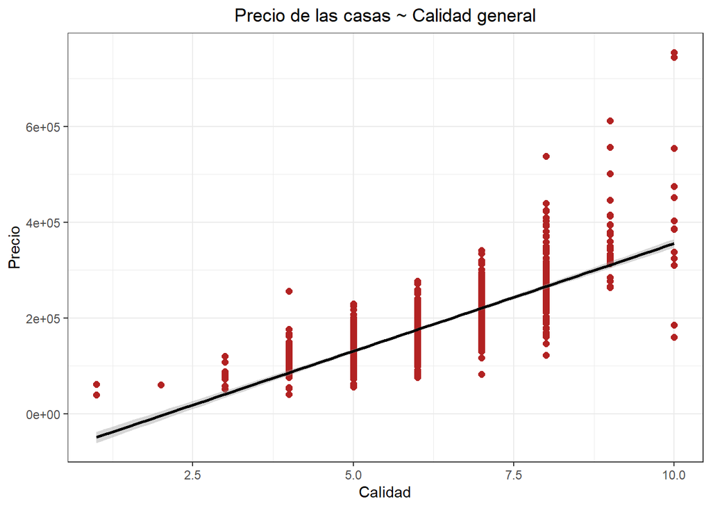

```r
library(ggplot2)
ggplot(data = training, mapping = aes(x = OverallQual, y = SalePrice)) +
geom_point(color = "firebrick", size = 2) +
geom_smooth(method = "lm", se = TRUE, color = "black") +
labs(title = "Precio de las casas ~ Calidad general", x = "Calidad", y = "Precio") +
theme_bw() + theme(plot.title = element_text(hjust = 0.5))
```

###Resumen del modelo:

```r
summary(datosunivar)
```

```
##
## Call:
## lm(formula = SalePrice ~ OverallQual, data = training)
##
## Residuals:
##     Min      1Q  Median      3Q     Max
## -195710  -29750   -1864   19723  399290
##
## Coefficients:
##             Estimate Std. Error t value Pr(>|t|)
## (Intercept)   -94156       6994  -13.46   <2e-16 ***
## OverallQual    44987       1116   40.30   <2e-16 ***
## ---
## Signif. codes:  0 '***' 0.001 '**' 0.01 '*' 0.05 '.' 0.1 ' ' 1
##
## Residual standard error: 49420 on 1019 degrees of freedom
## Multiple R-squared:  0.6145, Adjusted R-squared:  0.6141
## F-statistic:  1624 on 1 and 1019 DF,  p-value: < 2.2e-16
```

Como se puede notar ambos coeficientes son significativos, eso nos dice que la calidad general de las casas es un buen predictor de su precio. El valor de $R^2$ es de 0.61 que nos dice que el modelo es valido pero no es el mejor.

### Análisis de Residuales

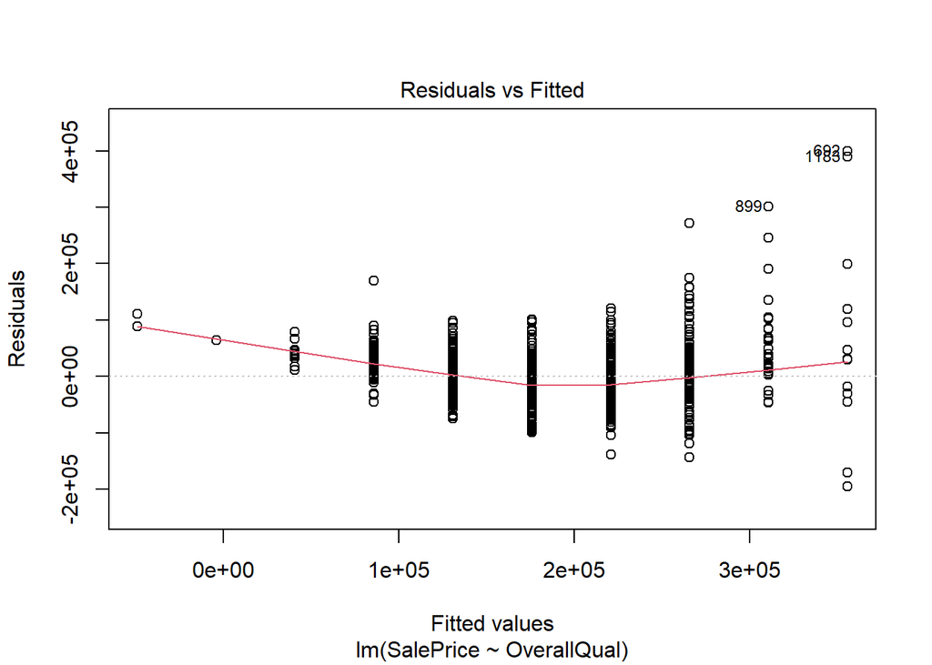

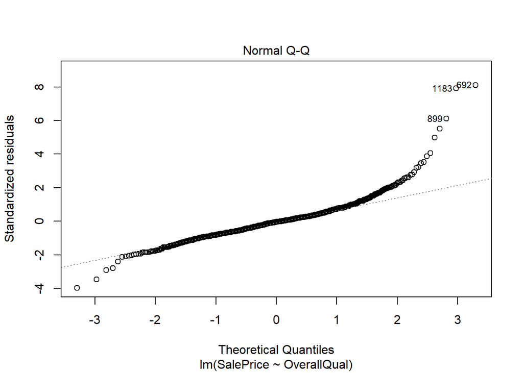

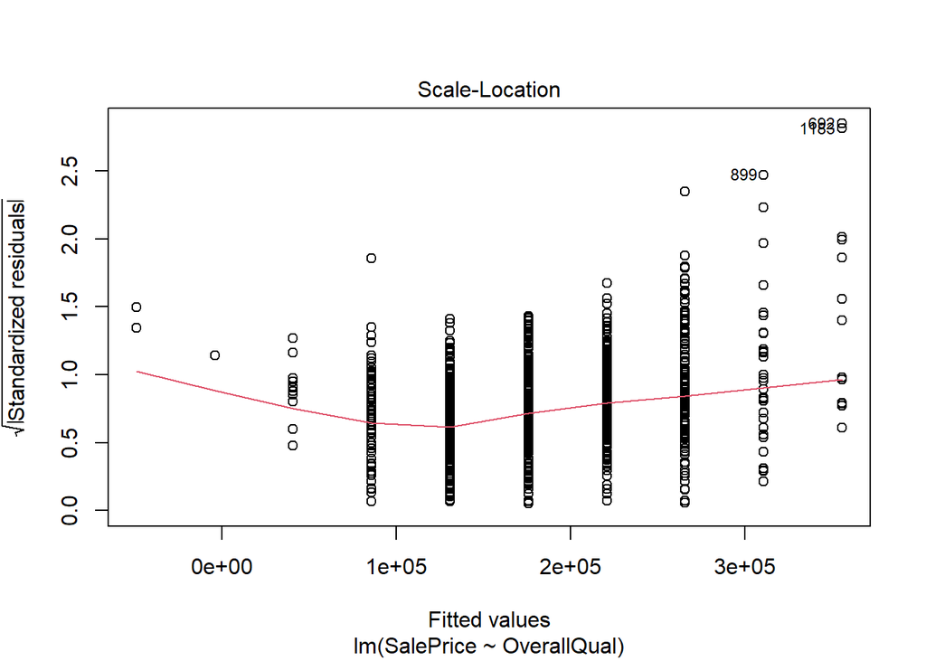

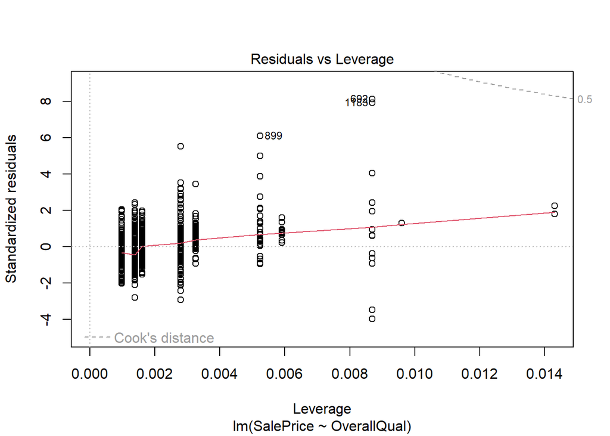

```r
plot(datosunivar)
```

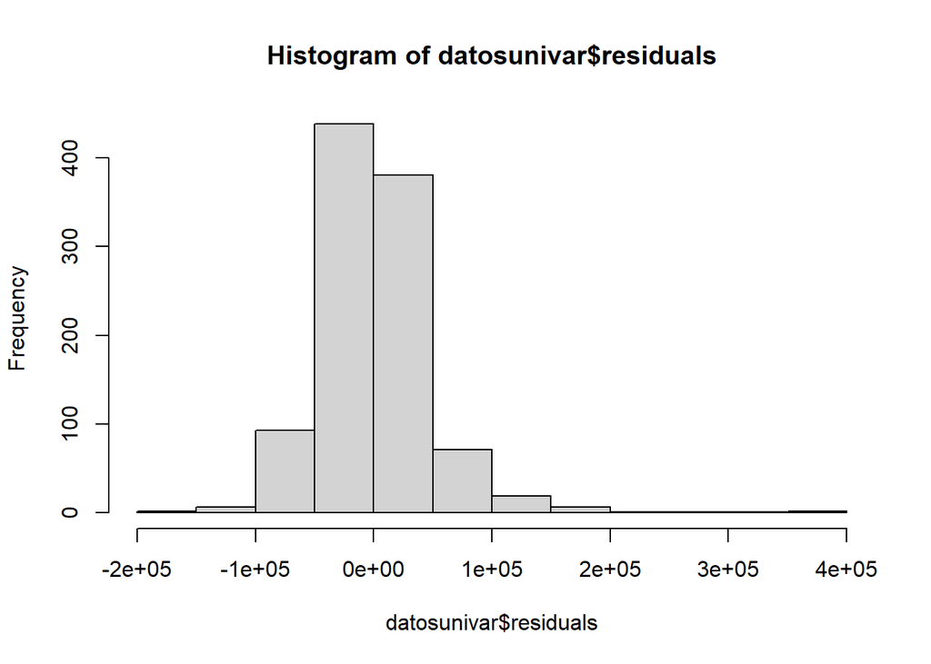

```r
hist(datosunivar$residuals)
```

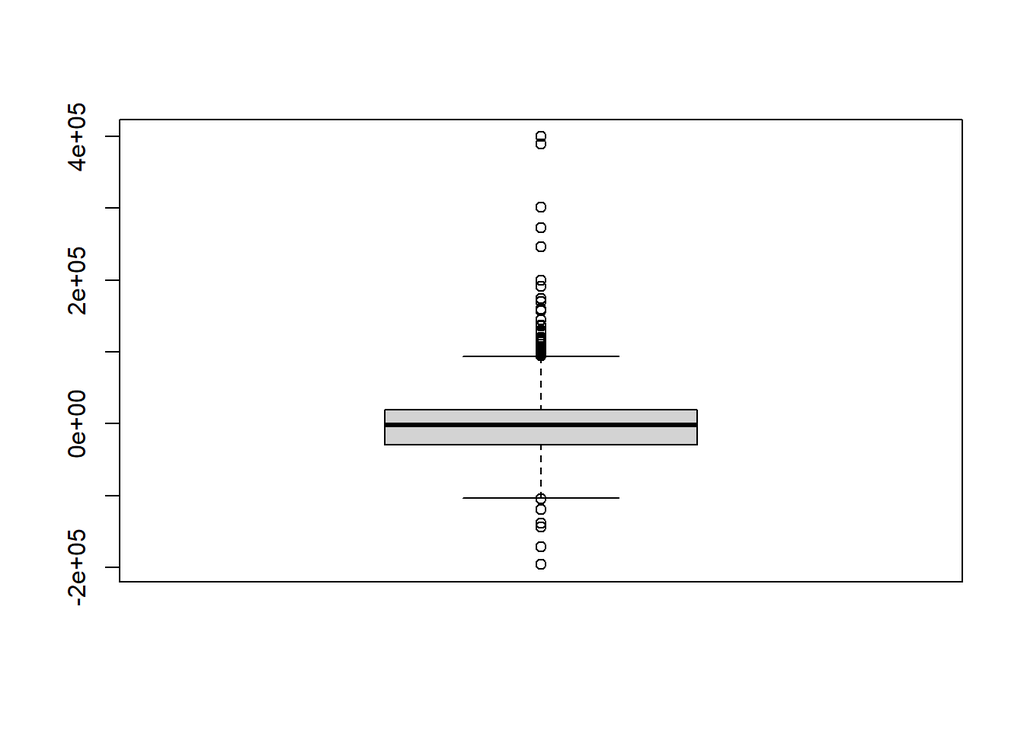

```r
boxplot(datosunivar$residuals)
```

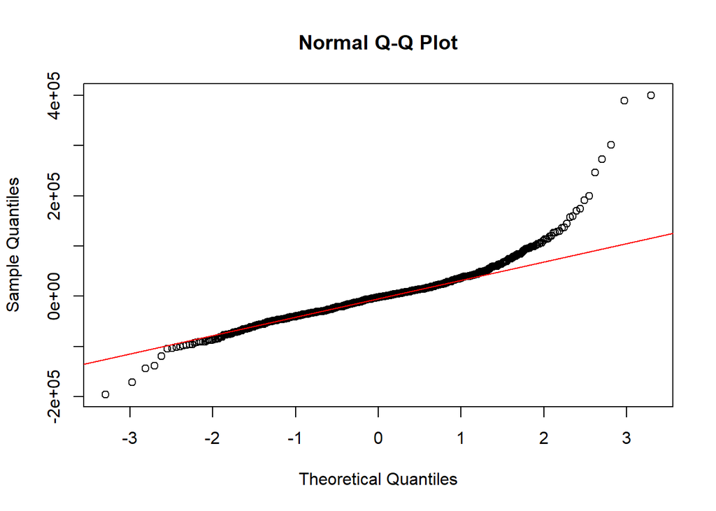

```r
qqnorm(datosunivar$residuals)
qqline(datosunivar$residuals, col="red")
```

###Prediccion de los datos

```r
predLM<-predict(datosunivar, newdata = test)
library(caret)
RMSE(predLM,test$SalePrice)
```

```
## [1] 46739.21
```

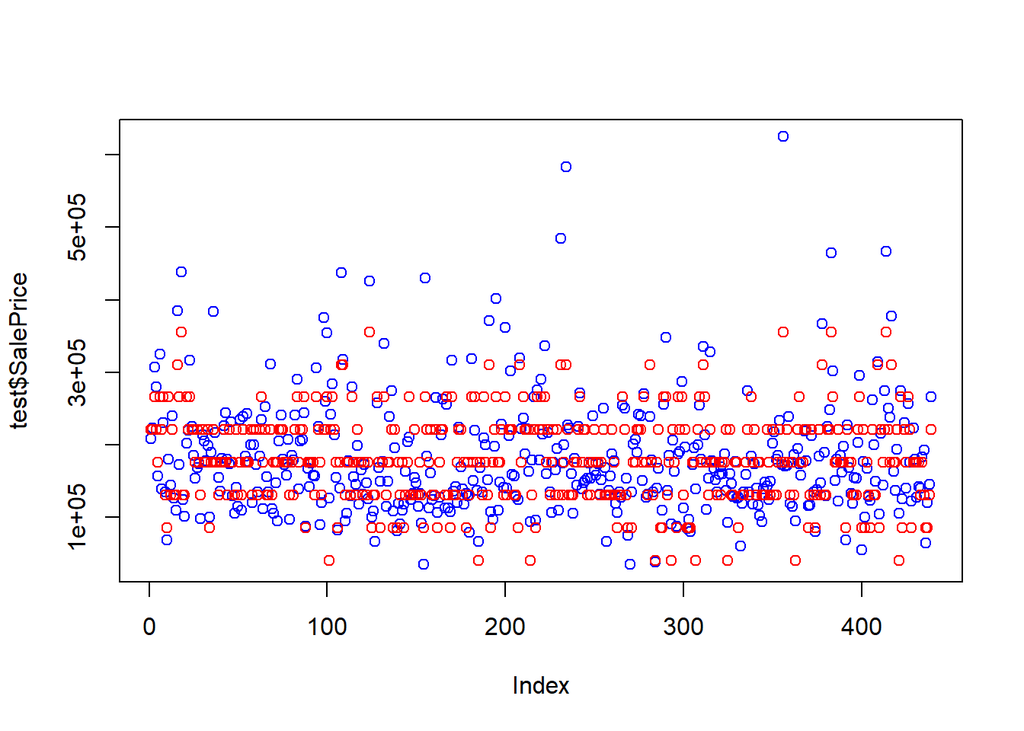

```r
plot(test$SalePrice,col="blue")
points(predLM, col="red")
```

```r
summary(test$SalePrice-predLM)
```

```
##     Min.  1st Qu.   Median     Mean  3rd Qu.     Max.
## -98750.3 -24820.3    668.4   2293.8  24223.0 272209.3
```

##Pregunta 8. Modelo regresión lineal multiple

```r
training1 <- dplyr::select_if(training, is.numeric)
training1 <- na.omit(training1)
datosmult<-lm(SalePrice~.,data = training1)
```

###Resumen del modelo:

```r
summary(datosmult)
```

```
##
## Call:
## lm(formula = SalePrice ~ ., data = training1)
##
## Residuals:
##     Min      1Q  Median      3Q     Max
## -384589  -18372   -2730   15759  338274
##
## Coefficients: (2 not defined because of singularities)
##                 Estimate Std. Error t value Pr(>|t|)
## (Intercept)   -1.018e+06  2.198e+06  -0.463 0.643418
## Id            -3.861e+00  3.459e+00  -1.116 0.264627
## MSSubClass    -2.299e+02  4.646e+01  -4.948 9.28e-07 ***
## LotFrontage   -1.798e+02  8.778e+01  -2.048 0.040893 *
## LotArea       -9.638e-02  3.653e-01  -0.264 0.792000
## OverallQual    1.971e+04  1.949e+03  10.112  < 2e-16 ***
## OverallCond    4.892e+03  1.810e+03   2.703 0.007029 **
## YearBuilt      3.251e+02  1.174e+02   2.769 0.005761 **
## YearRemodAdd   9.117e+01  1.123e+02   0.812 0.417055
## MasVnrArea     2.068e+01  9.431e+00   2.192 0.028675 *
## BsmtFinSF1     1.622e+01  7.752e+00   2.093 0.036685 *
## BsmtFinSF2     7.982e+00  1.160e+01   0.688 0.491518
## BsmtUnfSF      9.905e-01  6.940e+00   0.143 0.886545
## TotalBsmtSF           NA         NA      NA       NA
## X1stFlrSF      5.072e+01  9.625e+00   5.270 1.79e-07 ***
## X2ndFlrSF      4.442e+01  8.076e+00   5.500 5.23e-08 ***
## LowQualFinSF   4.985e+01  3.581e+01   1.392 0.164291
## GrLivArea             NA         NA      NA       NA
## BsmtFullBath   8.692e+03  4.100e+03   2.120 0.034350 *
## BsmtHalfBath   6.673e+03  7.022e+03   0.950 0.342233
## FullBath       6.410e+03  4.678e+03   1.370 0.171036
## HalfBath      -1.578e+02  4.300e+03  -0.037 0.970738
## BedroomAbvGr  -1.100e+04  2.813e+03  -3.911 0.000100 ***
## KitchenAbvGr  -2.750e+04  8.771e+03  -3.135 0.001785 **
## TotRmsAbvGrd   6.642e+03  1.931e+03   3.439 0.000616 ***
## Fireplaces     4.754e+03  2.817e+03   1.688 0.091916 .
## GarageYrBlt   -9.463e+01  1.250e+02  -0.757 0.449158
## GarageCars     1.737e+04  4.566e+03   3.804 0.000154 ***
## GarageArea     7.550e+00  1.546e+01   0.488 0.625467
## WoodDeckSF     3.104e+01  1.341e+01   2.314 0.020934 *
## OpenPorchSF   -8.597e+00  2.439e+01  -0.353 0.724562
## EnclosedPorch  1.261e+01  2.727e+01   0.462 0.643924
## X3SsnPorch     4.384e+01  4.239e+01   1.034 0.301340
## ScreenPorch    5.667e+01  2.687e+01   2.109 0.035295 *
## PoolArea      -9.879e+01  5.337e+01  -1.851 0.064577 .
## MiscVal       -4.810e+00  9.472e+00  -0.508 0.611729
## MoSold        -1.116e+02  5.509e+02  -0.202 0.839583
## YrSold         1.603e+02  1.092e+03   0.147 0.883293
## ---
## Signif. codes:  0 '***' 0.001 '**' 0.01 '*' 0.05 '.' 0.1 ' ' 1
##
## Residual standard error: 39370 on 736 degrees of freedom
## Multiple R-squared:  0.7929, Adjusted R-squared:  0.783
## F-statistic: 80.51 on 35 and 736 DF,  p-value: < 2.2e-16
```

### Análisis de Residuales

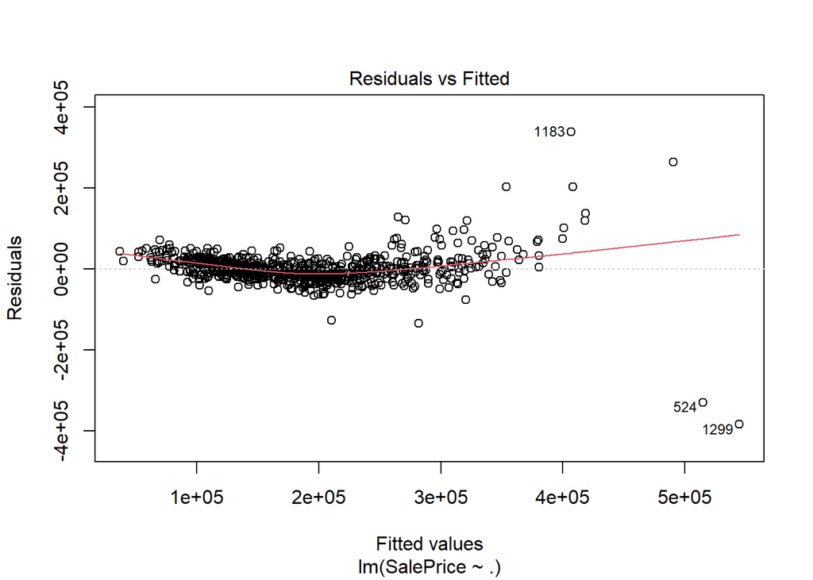

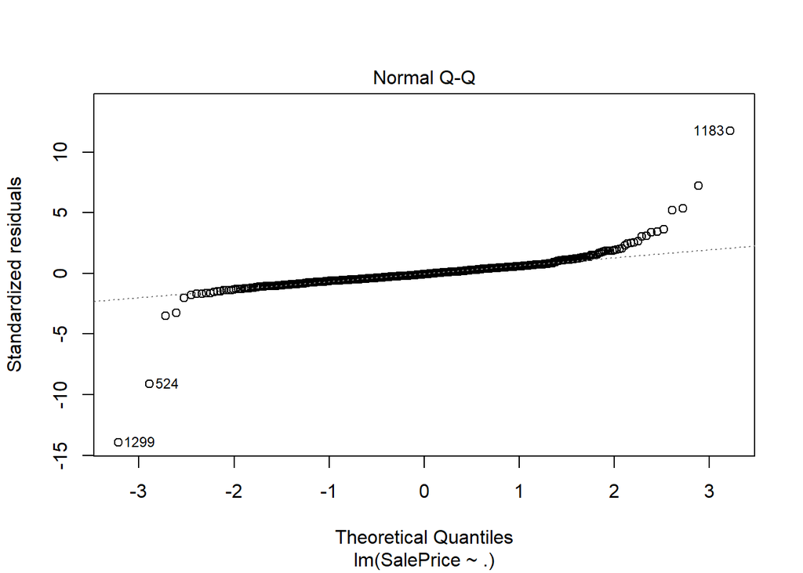

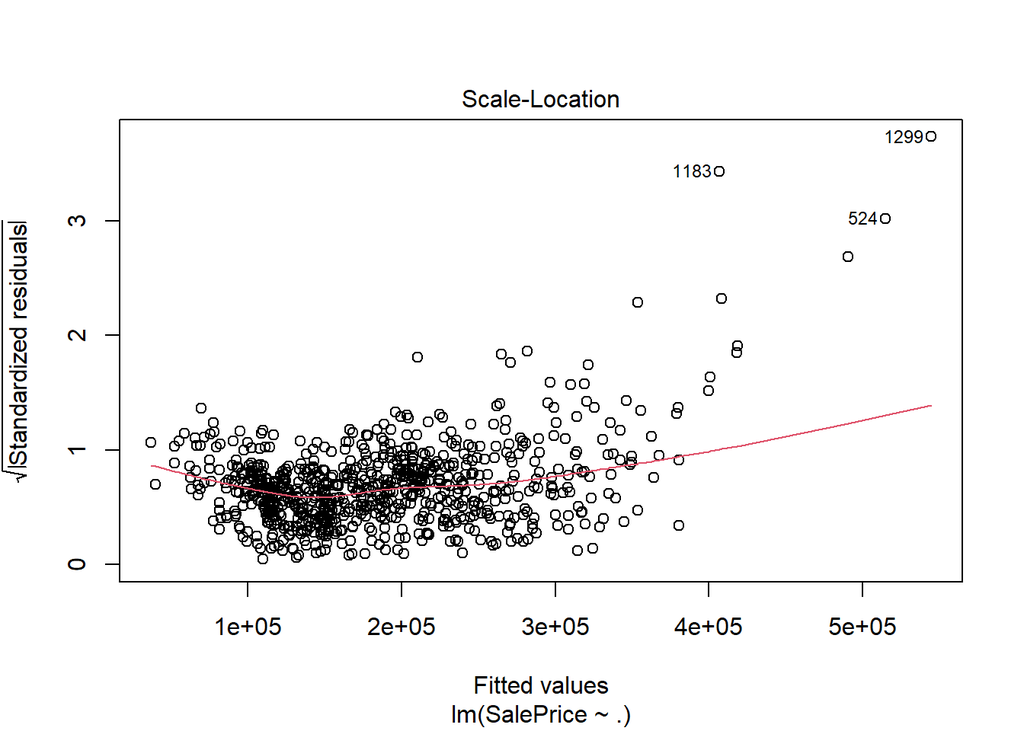

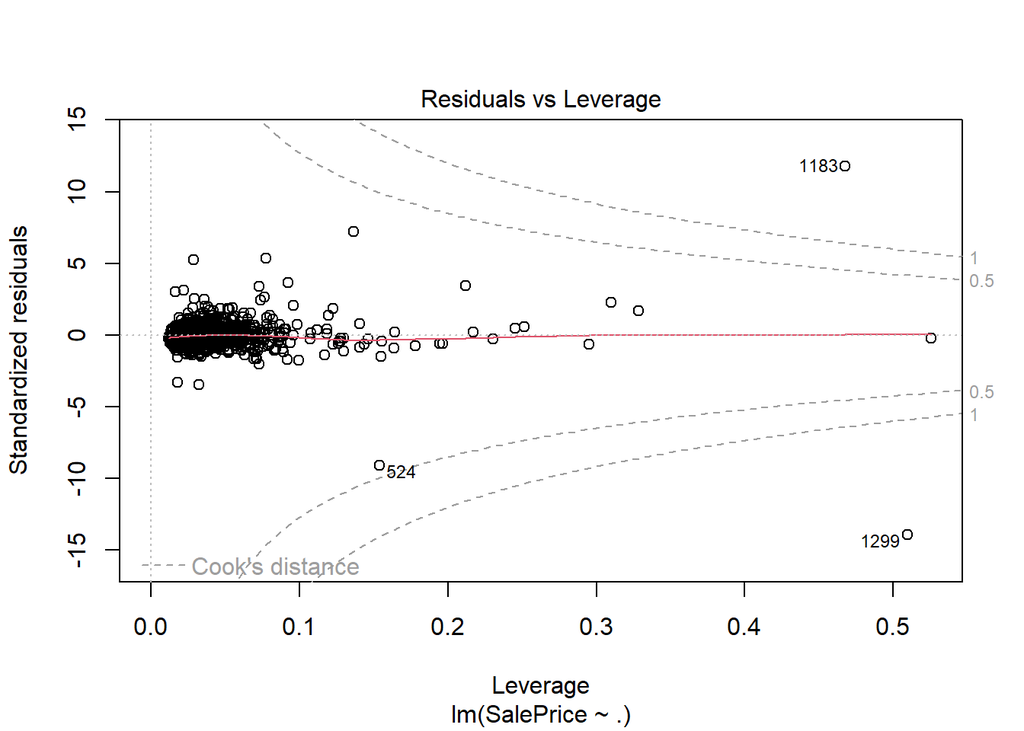

```r
plot(datosmult)
```

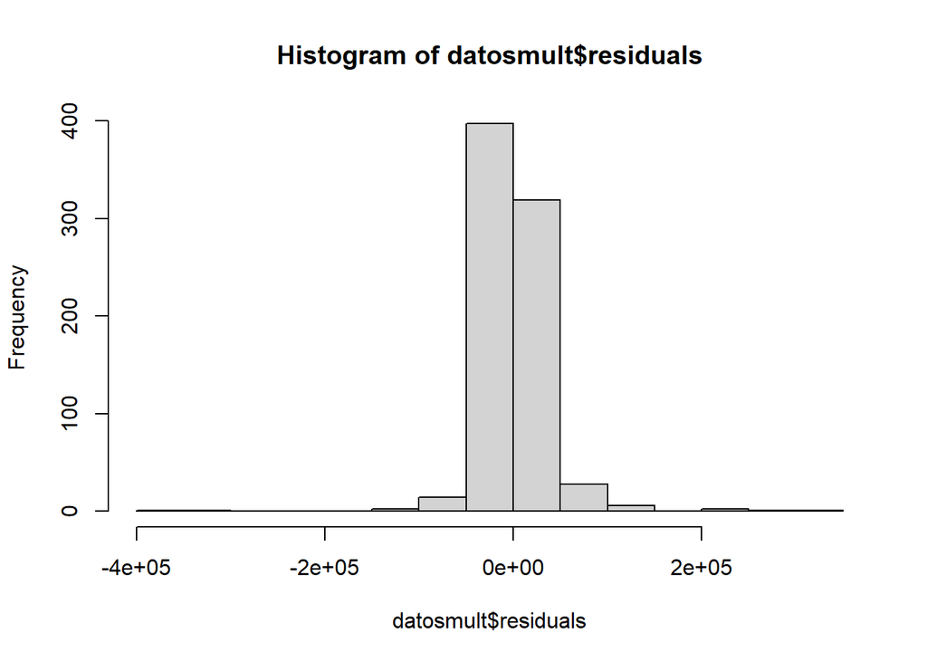

```r
hist(datosmult$residuals)
```

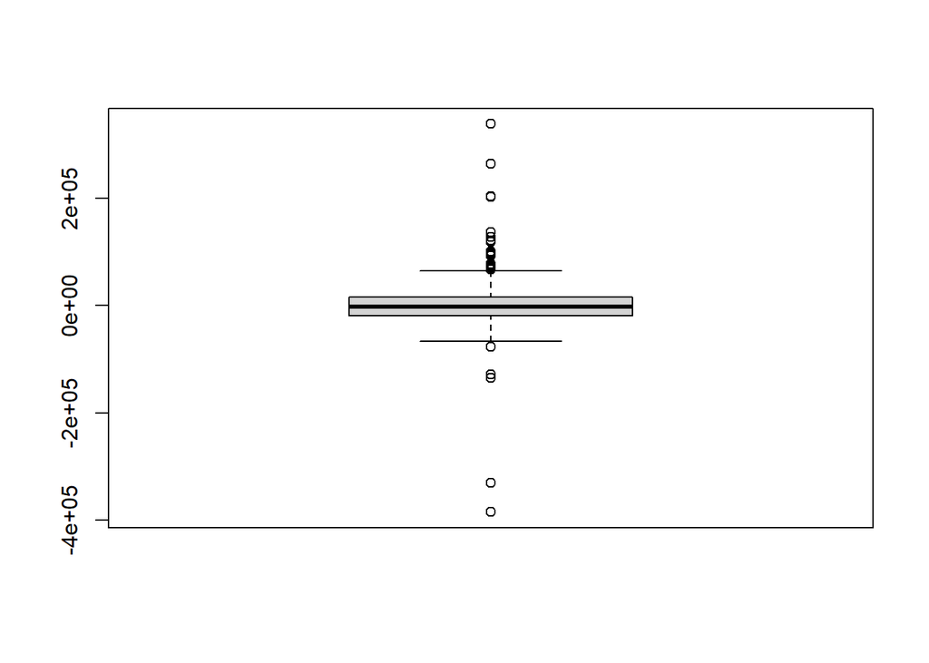

```r
boxplot(datosmult$residuals)
```

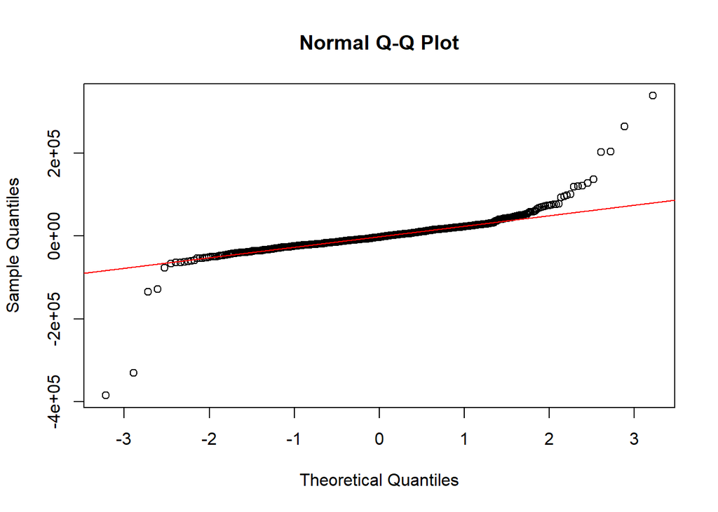

```r
qqnorm(datosmult$residuals)
qqline(datosmult$residuals, col="red")
```

###Prediccion de los datos

```r
pp<-predict(datosmult, newdata = test)
library(caret)
RMSE(pp,test$SalePrice)
```

```
## [1] NA
```

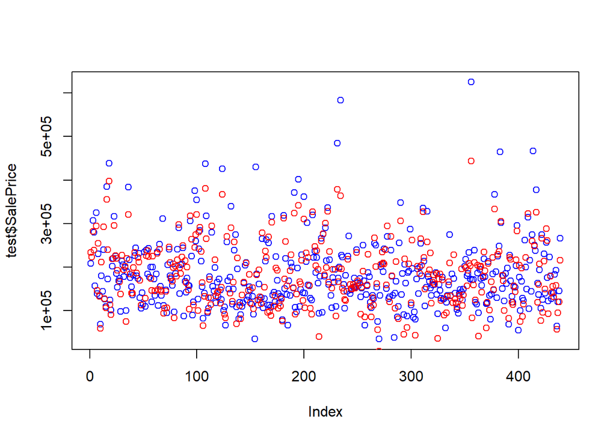

```r
plot(test$SalePrice,col="blue")
points(pp, col="red")
```

```r
summary(test$SalePrice-pp)
```

```
##     Min.  1st Qu.   Median     Mean  3rd Qu.     Max.     NA's
## -85555.5 -15899.0   -689.4   2677.3  18405.7 218847.5       90
```

Se observa que la predicción de las variables es buena pero podría mejorarse.

## Problema 9

```r
#datosmult<-lm(SalePrice~.,data = datos2)
training1 %>% cor(use="complete.obs",method="pearson") %>% round(digits=2) -> mat_cor
mat_cor
```

```
##                  Id MSSubClass LotFrontage LotArea OverallQual OverallCond
## Id             1.00       0.01       -0.02   -0.03       -0.03        0.02
## MSSubClass     0.01       1.00       -0.40   -0.27        0.03       -0.10
## LotFrontage   -0.02      -0.40        1.00    0.57        0.26       -0.04
## LotArea       -0.03      -0.27        0.57    1.00        0.24       -0.05
## OverallQual   -0.03       0.03        0.26    0.24        1.00       -0.17
## OverallCond    0.02      -0.10       -0.04   -0.05       -0.17        1.00
## YearBuilt     -0.01       0.04        0.14    0.09        0.60       -0.42
## YearRemodAdd  -0.01       0.01        0.10    0.07        0.57        0.03
## MasVnrArea    -0.06       0.01        0.25    0.20        0.43       -0.17
## BsmtFinSF1    -0.02      -0.07        0.29    0.31        0.25       -0.04
## BsmtFinSF2     0.06      -0.07        0.03    0.02       -0.08        0.03
## BsmtUnfSF     -0.03      -0.14        0.13    0.09        0.35       -0.15
## TotalBsmtSF   -0.03      -0.23        0.44    0.42        0.58       -0.17
## X1stFlrSF      0.00      -0.24        0.48    0.46        0.53       -0.16
## X2ndFlrSF      0.01       0.30        0.09    0.13        0.26       -0.01
## LowQualFinSF  -0.03       0.01       -0.03    0.01       -0.02        0.09
## GrLivArea      0.00       0.07        0.43    0.45        0.61       -0.12
## BsmtFullBath   0.03      -0.01        0.09    0.15        0.11       -0.05
## BsmtHalfBath  -0.04       0.03       -0.05   -0.04       -0.04        0.15
## FullBath       0.01       0.13        0.20    0.19        0.58       -0.24
## HalfBath      -0.01       0.18        0.07    0.09        0.25       -0.09
## BedroomAbvGr   0.04      -0.06        0.27    0.19        0.09       -0.02
## KitchenAbvGr  -0.02       0.26       -0.02   -0.03       -0.17       -0.11
## TotRmsAbvGrd   0.02       0.03        0.36    0.34        0.46       -0.11
## Fireplaces    -0.01      -0.03        0.27    0.32        0.44       -0.01
## GarageYrBlt   -0.01       0.05        0.11    0.08        0.58       -0.34
## GarageCars    -0.04      -0.04        0.31    0.23        0.62       -0.28
## GarageArea    -0.05      -0.11        0.40    0.33        0.56       -0.21
## WoodDeckSF     0.00      -0.03        0.13    0.20        0.28       -0.03
## OpenPorchSF   -0.01       0.03        0.16    0.18        0.34       -0.05
## EnclosedPorch  0.03      -0.04       -0.03   -0.06       -0.18        0.06
## X3SsnPorch    -0.07      -0.04        0.09    0.03        0.03       -0.02
## ScreenPorch    0.01      -0.03        0.04    0.12        0.05        0.10
## PoolArea       0.08       0.01        0.29    0.25        0.12       -0.03
## MiscVal        0.03      -0.05        0.01    0.03       -0.09        0.08
## MoSold         0.04       0.02       -0.04   -0.03        0.07       -0.01
## YrSold         0.00      -0.02        0.02   -0.02       -0.02       -0.01
## SalePrice     -0.04      -0.09        0.35    0.35        0.80       -0.12
##               YearBuilt YearRemodAdd MasVnrArea BsmtFinSF1 BsmtFinSF2 BsmtUnfSF
```

[output cut: 218 more lines]

```
## TotRmsAbvGrd         0.10     0.19    0.01   0.03  -0.05      0.55
## Fireplaces           0.22     0.16    0.04   0.04   0.00      0.48
## GarageYrBlt         -0.09     0.04   -0.06   0.01   0.00      0.52
## GarageCars           0.01     0.05   -0.05   0.04  -0.04      0.65
## GarageArea           0.00     0.13   -0.02   0.01  -0.02      0.61
## WoodDeckSF          -0.10     0.02   -0.01   0.01  -0.01      0.35
## OpenPorchSF          0.12     0.10    0.04   0.07  -0.05      0.33
## EnclosedPorch       -0.08    -0.02    0.03  -0.03   0.01     -0.18
## X3SsnPorch          -0.03    -0.01    0.03   0.03   0.01      0.04
## ScreenPorch          1.00     0.14    0.26   0.01  -0.01      0.10
## PoolArea             0.14     1.00    0.24  -0.03  -0.04      0.16
## MiscVal              0.26     0.24    1.00   0.04   0.02     -0.05
## MoSold               0.01    -0.03    0.04   1.00  -0.16      0.02
## YrSold              -0.01    -0.04    0.02  -0.16   1.00     -0.01
## SalePrice            0.10     0.16   -0.05   0.02  -0.01      1.00
```

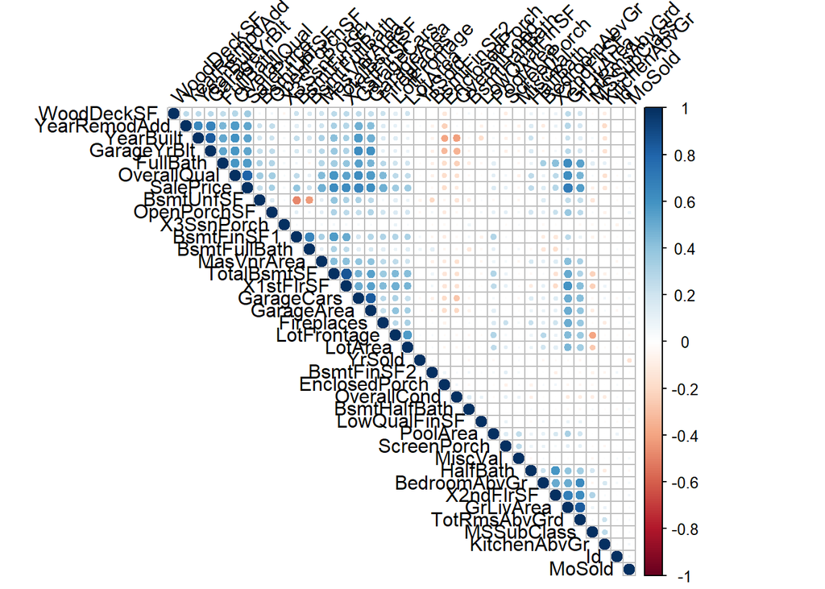

```r
library(corrplot)
corrplot(mat_cor, type="upper", order="hclust", tl.col="black", tl.srt=45)
```

Analisis: Como se mencionó al principio del informe y como se puede observar en la matriz de correlación, las variables de **OverallQual** y la de **GrLivArea** son las variables con coeficiente de correlacion mayor a 0.7 en relacion a la variable **SalePrice**(variable 7 en la matriz de correlaciones). Entonces SI existe colinealidad entre ciertas variables. Estas 2 variables que tienen multicolinealidad no deberian ser predictorias en el modelo, por lo que seria bueno analizar un modelo sin estas dos variables.

## Problema 10

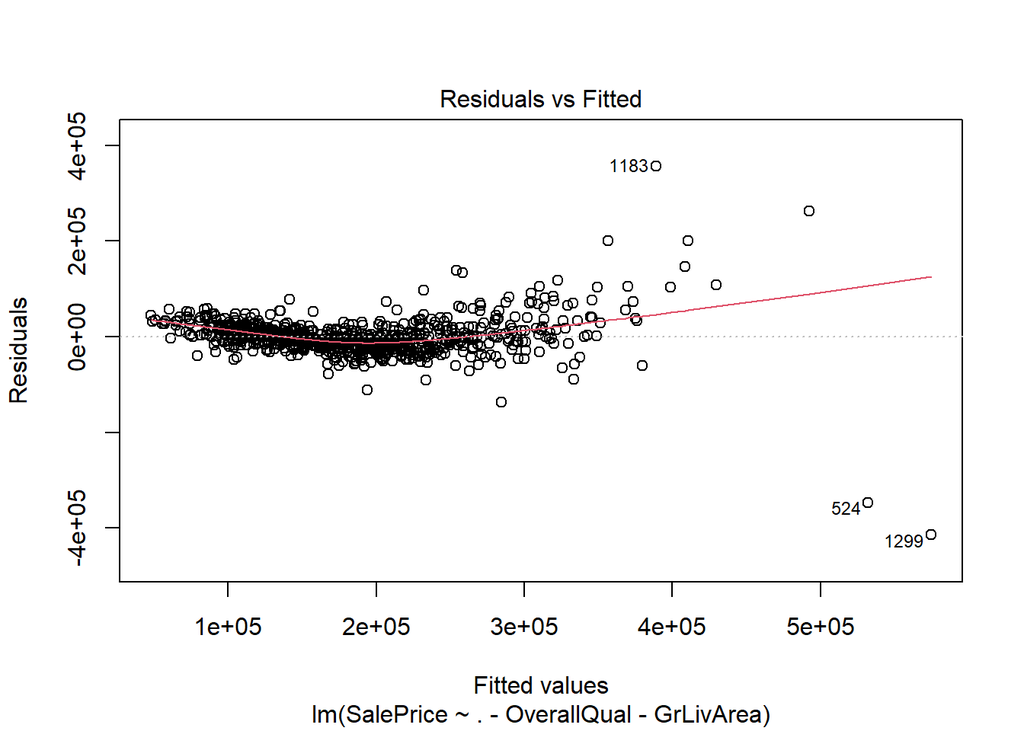

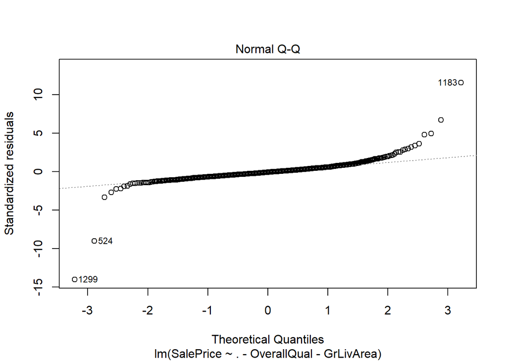

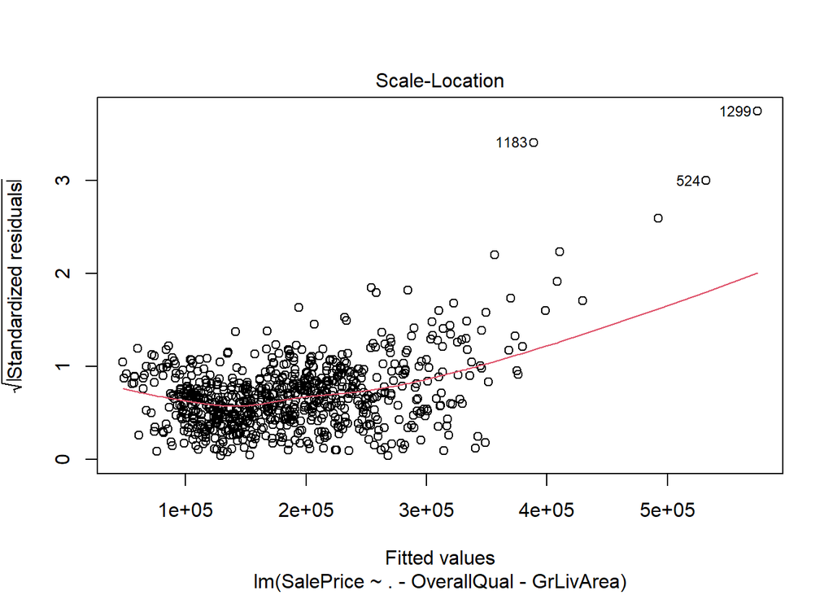

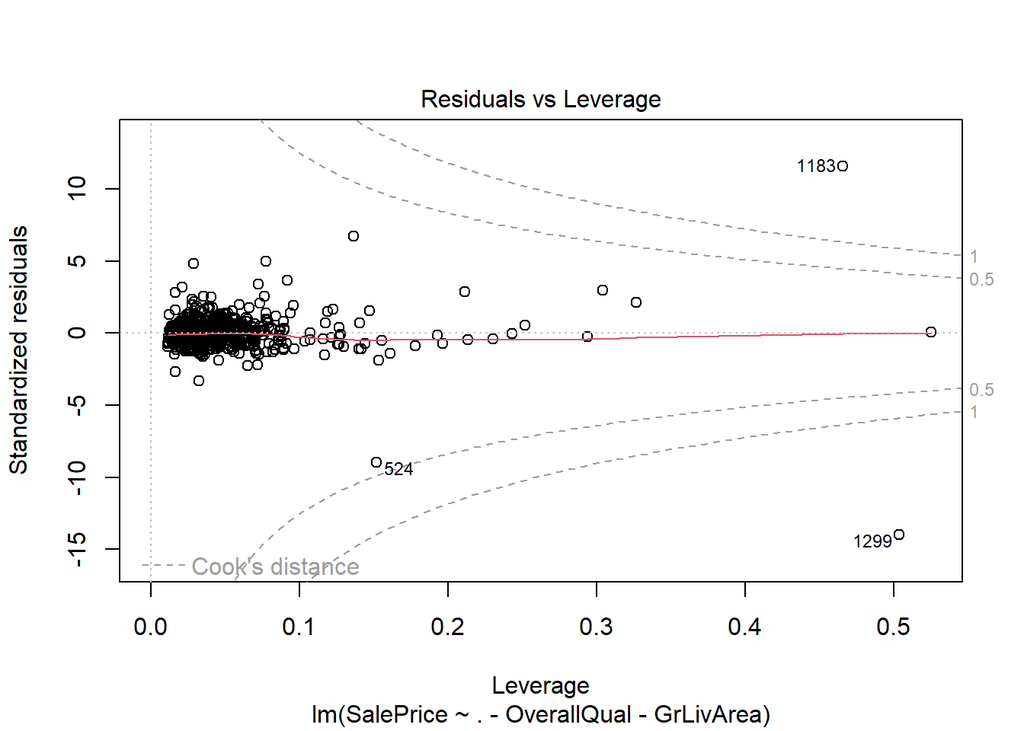

```r
datosmult1<-lm(SalePrice~. - OverallQual - GrLivArea,data = training1)
plot(datosmult1)
```

###Prediccion de los datos

```r
p1<-predict(datosmult1, newdata = test)
library(caret)
RMSE(p1,test$SalePrice)
```

```
## [1] NA
```

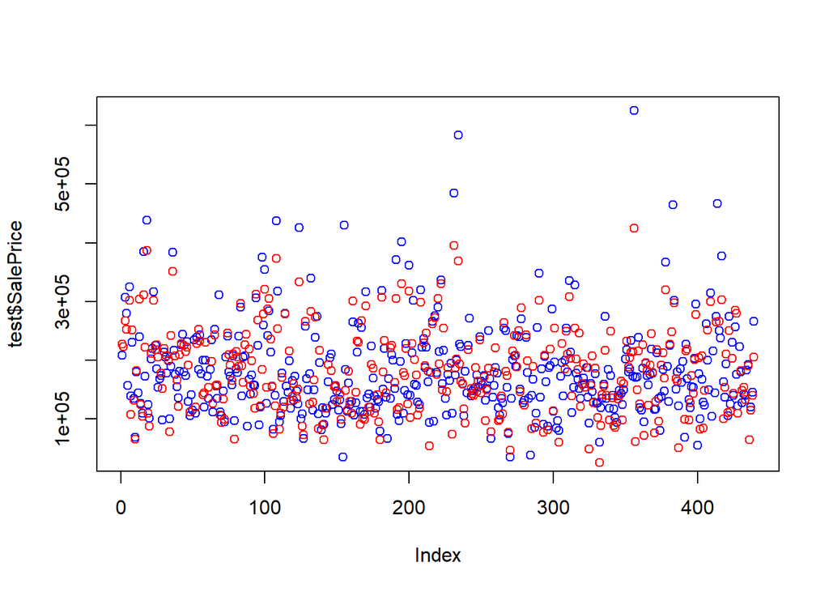

```r
plot(test$SalePrice,col="blue")
points(p1, col="red")
```

```r
summary(test$SalePrice-p1)
```

```
##    Min. 1st Qu.  Median    Mean 3rd Qu.    Max.    NA's
## -104331  -18660   -1044    2579   19732  214005      90
```

###Resumen del modelo:

```r
summary(datosmult1)
```

```
##
## Call:
## lm(formula = SalePrice ~ . - OverallQual - GrLivArea, data = training1)
##
## Residuals:
##     Min      1Q  Median      3Q     Max
## -414549  -19293   -2453   15195  356075
##
## Coefficients: (1 not defined because of singularities)
##                 Estimate Std. Error t value Pr(>|t|)
## (Intercept)   -2.013e+06  2.341e+06  -0.860 0.390156
## Id            -4.850e+00  3.687e+00  -1.315 0.188778
## MSSubClass    -1.911e+02  4.937e+01  -3.871 0.000118 ***
## LotFrontage   -1.869e+02  9.361e+01  -1.997 0.046194 *
## LotArea       -3.870e-01  3.884e-01  -0.996 0.319371
## OverallCond    6.886e+03  1.918e+03   3.589 0.000354 ***
## YearBuilt      6.013e+02  1.218e+02   4.938 9.77e-07 ***
## YearRemodAdd   1.920e+02  1.193e+02   1.609 0.107946
## MasVnrArea     2.587e+01  1.004e+01   2.576 0.010185 *
## BsmtFinSF1     2.779e+01  8.176e+00   3.399 0.000712 ***
## BsmtFinSF2     1.512e+01  1.235e+01   1.225 0.221075
## BsmtUnfSF      1.814e+01  7.177e+00   2.527 0.011708 *
## TotalBsmtSF           NA         NA      NA       NA
## X1stFlrSF      5.982e+01  1.022e+01   5.853 7.27e-09 ***
## X2ndFlrSF      5.837e+01  8.487e+00   6.877 1.30e-11 ***
## LowQualFinSF   7.162e+01  3.812e+01   1.879 0.060665 .
## BsmtFullBath   8.781e+03  4.373e+03   2.008 0.044986 *
## BsmtHalfBath   6.662e+03  7.488e+03   0.890 0.373958
## FullBath       9.290e+03  4.980e+03   1.866 0.062508 .
## HalfBath      -9.278e+02  4.585e+03  -0.202 0.839716
## BedroomAbvGr  -1.559e+04  2.961e+03  -5.266 1.83e-07 ***
## KitchenAbvGr  -4.566e+04  9.156e+03  -4.987 7.66e-07 ***
## TotRmsAbvGrd   8.951e+03  2.045e+03   4.376 1.38e-05 ***
## Fireplaces     9.729e+03  2.958e+03   3.289 0.001052 **
## GarageYrBlt   -1.114e+02  1.333e+02  -0.836 0.403425
## GarageCars     2.337e+04  4.828e+03   4.841 1.57e-06 ***
## GarageArea     7.025e+00  1.649e+01   0.426 0.670181
## WoodDeckSF     2.923e+01  1.430e+01   2.043 0.041365 *
## OpenPorchSF    6.040e-01  2.599e+01   0.023 0.981466
## EnclosedPorch  3.733e+01  2.896e+01   1.289 0.197818
## X3SsnPorch     4.183e+01  4.521e+01   0.925 0.355075
## ScreenPorch    6.583e+01  2.864e+01   2.298 0.021825 *
## PoolArea      -1.271e+02  5.684e+01  -2.236 0.025682 *
## MiscVal       -1.026e+01  1.009e+01  -1.018 0.309139
## MoSold         5.235e+02  5.837e+02   0.897 0.370078
## YrSold         3.392e+02  1.164e+03   0.291 0.770840
## ---
## Signif. codes:  0 '***' 0.001 '**' 0.01 '*' 0.05 '.' 0.1 ' ' 1
##
## Residual standard error: 41990 on 737 degrees of freedom
## Multiple R-squared:  0.7641, Adjusted R-squared:  0.7532
## F-statistic: 70.22 on 34 and 737 DF,  p-value: < 2.2e-16
```

## Problema 11

Abajo se muestran ambas predicciones para ambos modelos aplicados al conjunto de prueba. Para el modelo en el cual se quitan las variables colineales, analizando el error cuadratico medio(RMSE) podemos observar que tenemos una error de 36,242.3 y para el modelo en el cual se quedan estas variables tenemos un error de 32,741.98 para el precio de las casas. Comparando este error con la desviacion estandar que resultó ser de 79,602.17, en ambos casos el error se mantiene al rededor de la mitad de la desviación por lo que podemos decir que los modelos hicieron predicciones satisfactorias más no óptimas. De estos dos modelos el que mejor lo hizo fue el modelo donde se dejaron las variables ya que su error fue menor.

### Modelo sin variables con multicolinealidad

```r
datosmult1<-lm(SalePrice~. - OverallQual - GrLivArea,data = training1)
test1 <- dplyr::select_if(test, is.numeric)
test1 <- na.omit(test1)
pred<-predict(datosmult1,newdata = test1)
RMSE(pred,test1$SalePrice)
```

```
## [1] 36242.3
```

```r
sd(test1$SalePrice)
```

```
## [1] 79602.17
```

### Modelo con variables con multicolinealidad

```r
datosmult2<-lm(SalePrice~. ,data = training1)
test1 <- dplyr::select_if(test, is.numeric)
test1 <- na.omit(test1)
pred2<-predict(datosmult2,newdata = test1)
RMSE(pred2,test1$SalePrice)
```

```
## [1] 32741.98
```

## Problema 12

Al comparar las predicciones de ambos modelos observamos que el mejor modelo es con las variables con multicolinealidad. Ya que, variables que tenían una correlación significativa con el precio de venta fueron eliminadas para el segundo modelo, siendo OverallQuall y GrLivArea las que tenía la correlación más alta con el precio de venta pero al ser una variable categórica.Por otro lado, estas variables que tenías una correlación significativa con el precio de venta si fueron tomadas en cuenta en el modelo. Observamos que con respecto al R cuadrado el modelo con variables tiene un R cuadrado de 0.78 y el sin variables un 0.75 lo que nos indica que el modelo con las variables tiene mejor relación y mayor prodiccion al respecto de nuestros datos. (Los graficos son los realizados para las predicciones de los modelos y las tablas se encuentran en el resumen de cada modelo).